# Classification problem of Bank’s Telemarketing Campaign_Project 3

### Confusion Matrix

```python
# Build  a confutation matrix with percentage and storing
# "True Neg","False Pos","False Neg","True Pos"

tn, fp, fn, tp = confusion_matrix(y_test,y_pred_rf).ravel()
```

```python
# Display

tn, fp, fn, tp
```

```
(8529, 608, 698, 459)
```

```python
# Confusion matrix

cf_matrix = confusion_matrix(y_test,y_pred_rf)
cf_matrix
```

```
array([[8529,  608],
       [ 698,  459]])
```

```python
# Storing results

tn, fp, fn, tp = cf_matrix.ravel()
```

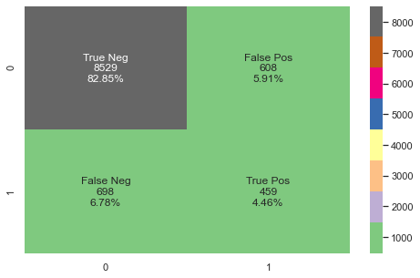

```python
# Customizing the matrix

# Adding names
group_names = ["True Neg","False Pos","False Neg","True Pos"]
group_counts = ["{0:0.0f}".format(value) for value in cf_matrix.flatten()]

# Formatting and adding percentages
group_percentages = ["{0:.2%}".format(value) for value in cf_matrix.flatten()/np.sum(cf_matrix)]

# Connecting the names with the numbers

labels = [f"{v1}\n{v2}\n{v3}" for v1, v2, v3 in zip(group_names,group_counts,group_percentages)]

# Apply heat map
labels = np.asarray(labels).reshape(2,2)
sns.heatmap(cf_matrix, annot=labels, fmt='', cmap='Accent')
plt.show()
```

#### Conclusions:

In this project,we implemented data analysis and predictive classified models to predict term deposit subscriptions at a Portuguese bank institution. With the F1 score of 87% using Random Forest Classifier, the following business recommendations are:

- Pay close attention to socioeconomic data: 3 Month Euribor rate - The Euribor rate is based on the average interest rates at which Eurozone banks lend funds to other banks. Ramp up the campaign when rates are high. A prospect is more likely to invest in a term deposit knowing that they will receive a high interest rate. Consumer Confidence Index - Individuals are more likely to invest if their financial situation is good and if the country’s outlook is optimistic.
- Target telemarketing calls toward select the individuals who belong to a specific age group and occupation. Seniors, and Students, and Retired Individuals are more likely to subscribe to a term deposit.
- Conduct the campaign during specific months. March, September, and October have been shown to have a higher rate of subscriptions.

[figure not shown]